## This script is to instruct people to analyze data from split-plot design and hierachical design

First create a data set about wheat and herbicide, learning the effects of wheat variety(A0,A1),and rates of a herbicide(B0,B1,B2,B3)

design as follows: 3 blocks(replicates), in each block there are two plots (whole-plot) to grow a varietey of wheat; Besides, the whole-plot is divided into four sub-plots to apply different rates of a herbicide.

```r
rm(list=ls())  # clean up memory
Dat <- data.frame(list(
  observation = 1:24,
  replicate = rep(c("I","II","III"),each =8),
  A = rep(rep(c("A0","A1"),each = 4),3),
  B = rep(c("B0","B1","B2","B3"),times = 6 ),
  yield = c(13.8,15.5,21.0,18.9,19.3,22.2,25.3,25.9,
            13.5,15.0,22.7,18.3,18.0,24.2,24.8,26.7,
            13.2,15.2,22.3,19.6,20.5,25.4,28.4,27.6)
  ))
```

Without knowledge of the design, the analysis below is not accurate.

```r
aov.bad <- aov(yield~replicate+ A*B, data =Dat)
summary(aov.bad)
```

```
##             Df Sum Sq Mean Sq F value   Pr(>F)
## replicate    2   7.87    3.93   4.486   0.0312 *
## A            1 262.02  262.02 298.862 7.68e-11 ***
## B            3 215.26   71.75  81.843 4.08e-09 ***
## A:B          3  18.70    6.23   7.109   0.0039 **
## Residuals   14  12.27    0.88
## ---
## Signif. codes:  0 '***' 0.001 '**' 0.01 '*' 0.05 '.' 0.1 ' ' 1
```

```r
#Library
library(agricolae)
## if we think replicates, no blocking effect
aov.good<- aov(yield~ A*B+Error(replicate:A), data =Dat)
summary(aov.good)
```

```
##
## Error: replicate:A
##           Df Sum Sq Mean Sq F value   Pr(>F)
## A          1  262.0  262.02   81.24 0.000839 ***
## Residuals  4   12.9    3.23
## ---
## Signif. codes:  0 '***' 0.001 '**' 0.01 '*' 0.05 '.' 0.1 ' ' 1
##
## Error: Within
##           Df Sum Sq Mean Sq F value   Pr(>F)
## B          3 215.26   71.75  118.96 3.43e-09 ***
## A:B        3  18.70    6.23   10.33  0.00121 **
## Residuals 12   7.24    0.60
## ---
## Signif. codes:  0 '***' 0.001 '**' 0.01 '*' 0.05 '.' 0.1 ' ' 1
```

```r
## if we think we need consider block effect. put replicate in the model
aov.good2<- aov(yield~ replicate + A*B + Error(replicate:A), data =Dat)
summary(aov.good2)
```

```
##
## Error: replicate:A
##           Df Sum Sq Mean Sq F value  Pr(>F)
## replicate  2   7.87    3.93   1.562 0.39032
## A          1 262.02  262.02 104.062 0.00947 **
## Residuals  2   5.04    2.52
## ---
## Signif. codes:  0 '***' 0.001 '**' 0.01 '*' 0.05 '.' 0.1 ' ' 1
##
## Error: Within
##           Df Sum Sq Mean Sq F value   Pr(>F)
## B          3 215.26   71.75  118.96 3.43e-09 ***
## A:B        3  18.70    6.23   10.33  0.00121 **
## Residuals 12   7.24    0.60
## ---
## Signif. codes:  0 '***' 0.001 '**' 0.01 '*' 0.05 '.' 0.1 ' ' 1
```

Do some diagnosis to check the assumptions, mainly on the residuals

```r
#diagnosis
aov.good3<- aov(yield~ replicate + A+replicate:A +  B  + A:B, data =Dat)
summary(aov.good3)
```

```
##             Df Sum Sq Mean Sq F value   Pr(>F)
## replicate    2   7.87    3.93   6.520  0.01211 *
## A            1 262.02  262.02 434.388 8.61e-11 ***
## B            3 215.26   71.75 118.956 3.43e-09 ***
## replicate:A  2   5.04    2.52   4.174  0.04206 *
## A:B          3  18.70    6.23  10.333  0.00121 **
## Residuals   12   7.24    0.60
## ---
## Signif. codes:  0 '***' 0.001 '**' 0.01 '*' 0.05 '.' 0.1 ' ' 1
```

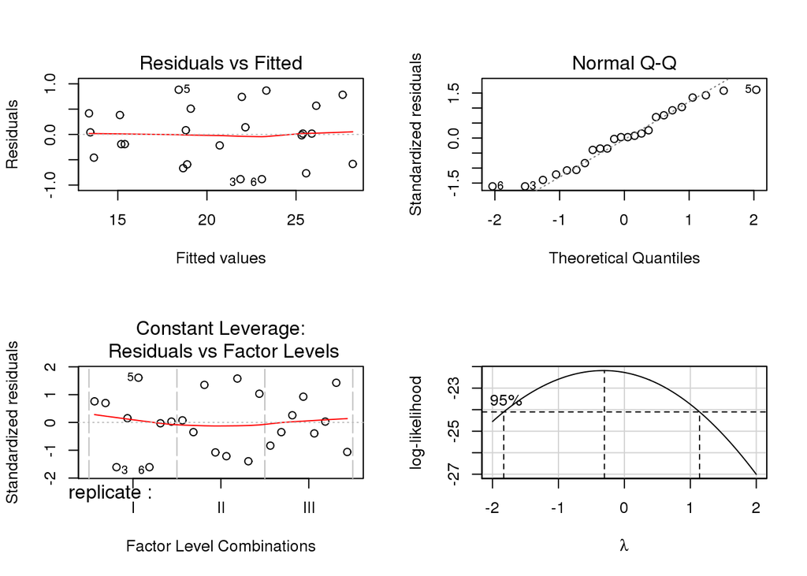

```r
layout(matrix(1:4,2,byrow = T))
plot(aov.good3, 1)
plot(aov.good3, 2)
plot(aov.good3, 5)
library(car)
boxCox(aov.good3)
```

```r
layout(1)
```

## Part 2: R code to analyze hierarchical design. The table is from table 9.8 on page 350.

The hierarchical model is : $Y_{ijk} = \mu +\alpha_i + \beta_{(i)j}+\epsilon_{ijk}$

where: $\mu$: constant; overall mean

$\alpha_i$: constant for ith treatment group; deviation from mean of i

$\beta_ij$: a random effect due to the ith group nested witin the jth experimental unit

$\epsilon_{ijk}$: andom deviation associated with each observation

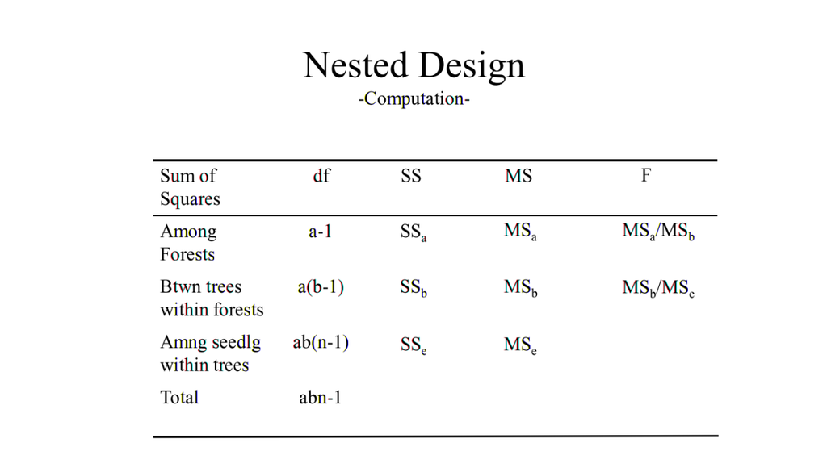

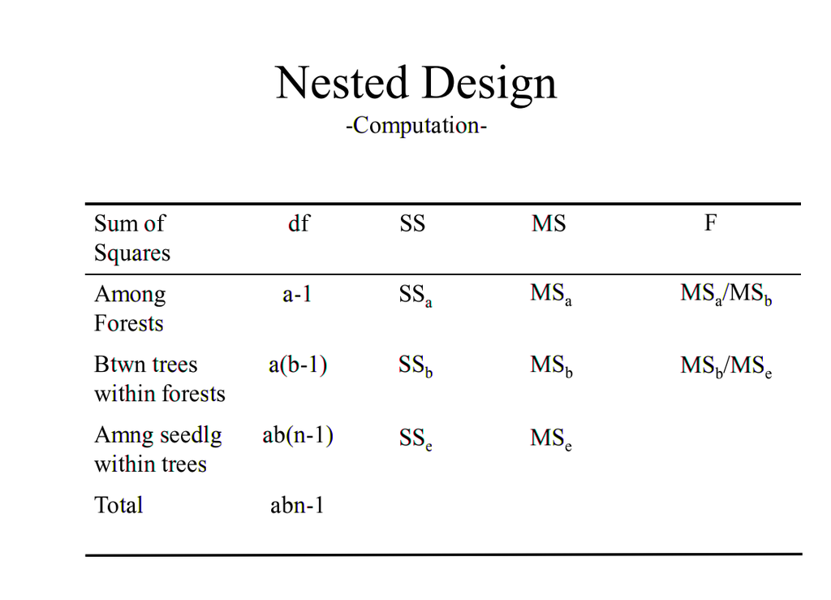

```r
knitr::include_graphics("nested.png")
```

```r
pigment <- data.frame(list(
  batch = rep(1:15,each=4),
  sample = rep(1:30,each =2),
  test = 1:60,
  y = c( 40,39,30,30,26,28,25,26,29,28,14,15,30,31,24,24,
         19,20,17,17,33,32,26,24,23,24,32,33,34,34,29,29,
         27,27,31,31,13,16,27,24,25,23,25,27,29,29,31,32,
         19,20,29,30,23,23,25,25,39,37,26,28)
  ))
pigment$batch <- as.factor(pigment$batch)
pigment$sample <- as.factor(pigment$sample)
pigment$test <- as.factor(pigment$test)
aov.pigment <- aov(y~batch+sample+test,data=pigment)
summary(aov.pigment)
```

```
##             Df Sum Sq Mean Sq
## batch       14 1216.2   86.87
## sample      15  871.5   58.10
## test        30   27.0    0.90
```

```r
#another method:
anova(lm(y~batch/sample,data=pigment))  #test part is just random noise
```

```
## Analysis of Variance Table
##
## Response: y
##              Df Sum Sq Mean Sq F value    Pr(>F)
## batch        14 1216.2  86.874  96.526 < 2.2e-16 ***
## batch:sample 15  871.5  58.100  64.556 < 2.2e-16 ***
## Residuals    30   27.0   0.900
## ---
## Signif. codes:  0 '***' 0.001 '**' 0.01 '*' 0.05 '.' 0.1 ' ' 1
```